# CMPT 459.1-19. Programming Assignment 3

FIFA 19 Players

Felix Sam

### Introduction

The data has detailed attributes for every player registered in the latest edition of FIFA 19 database, obtained scraping the website “sofifa.com”. Each instance is a different player, and the attributes give basic information about the players and their football skills. Basic pre-processing was done and Goal Keepers were removed for this assignment.

Please look here for the original data overview and attributes’ descriptions:

- https://www.kaggle.com/karangadiya/fifa19

And here to get a better view of the information:

- https://sofifa.com/

### Reading the data

```r
train <- read.csv('fifa-train.csv')
test <- read.csv('fifa-test.csv')
```

#### Remove insignificant attributes from training data

- Removed attributes that are deemed statistically insignificant when training using “glm”
- From Programming Assignment 2

```r
# Create "train_selec"
# Remove attributes with large P(>|z|)
# P(>|z|) > 0.05 is deemed statistically insignificant
train_selec <- train[, !names(train) %in%
                       c("Age",
                         "Value",
                         "Height",
                         "Weight",
                         "Crossing",
                         "Volleys",
                         "Dribbling",
                         "BallControl",
                         "Acceleration",
                         "SprintSpeed",
                         "Agility",
                         "Balance",
                         "ShotPower",
                         "Jumping",
                         "Stamina",
                         "LongShots",
                         "Aggression",
                         "SlidingTackle",
                         "Preferred.Foot",
                         "Penalties",
                         "Release.Clause"
                         )]
```

### Scenario A - Focus on prediction accuracy, not interested in interpretability

**[Task 1]**: (20 marks) Focusing on using the dataset for prediction and not needing to interpret the models, use the train dataset to create 2 models (one using Random Forest and the other Extreme Gradient Boosting), for predicting “Defense”. Use 10-fold cross validation for tuning. Report the confusion matrix and accuracy for each of the models on the test dataset.

#### Model using Random Forest

```r
library(caret)
set.seed(1)
model_rf <- train(Defense ~.,
               data = train_selec,
               method = "rf",
               preProcess = c("center","scale"), #Normalize
               trControl = trainControl(method = "cv", number = 10) # Add Cross-Validation, 10 folds
               )
```

```r
model_rf
```

```
## Random Forest
##
## 8968 samples
##   15 predictor
##    2 classes: 'No', 'Yes'
##
## Pre-processing: centered (14), scaled (14)
## Resampling: Cross-Validated (10 fold)
## Summary of sample sizes: 8070, 8071, 8072, 8070, 8071, 8071, ...
## Resampling results across tuning parameters:
##
##   mtry  Accuracy   Kappa
##    2    0.8997546  0.7995123
##    8    0.8973018  0.7946071
##   14    0.8964092  0.7928217
##
## Accuracy was used to select the optimal model using the largest value.
## The final value used for the model was mtry = 2.
```

#### Model using Extreme Gradient Boosting

```r
library(xgboost)

set.seed(1)
model_xgb <- train(Defense ~.,
                          data = train,
                          method = "xgbTree",
                          preProcess = c("center","scale"), #Normalize
                          trControl = trainControl(method = "cv", number = 10) # Add Cross-Validation, 10 folds
                          )
```

```r
model_xgb
```

```
## eXtreme Gradient Boosting
##
## 8968 samples
##   36 predictor
##    2 classes: 'No', 'Yes'
##
## Pre-processing: centered (35), scaled (35)
## Resampling: Cross-Validated (10 fold)
## Summary of sample sizes: 8070, 8071, 8072, 8070, 8071, 8071, ...
## Resampling results across tuning parameters:
##
##   eta  max_depth  colsample_bytree  subsample  nrounds  Accuracy
##   0.3  1          0.6               0.50        50      0.8083179
##   0.3  1          0.6               0.50       100      0.8123312
##   0.3  1          0.6               0.50       150      0.8143386
##   0.3  1          0.6               0.75        50      0.8078713
##   0.3  1          0.6               0.75       100      0.8124421
##   0.3  1          0.6               0.75       150      0.8146746
##   0.3  1          0.6               1.00        50      0.8057559
##   0.3  1          0.6               1.00       100      0.8097681
##   0.3  1          0.6               1.00       150      0.8117744
##   0.3  1          0.8               0.50        50      0.8048620
##   0.3  1          0.8               0.50       100      0.8102129
##   0.3  1          0.8               0.50       150      0.8086503
##   0.3  1          0.8               0.75        50      0.8072034
##   0.3  1          0.8               0.75       100      0.8096551
##   0.3  1          0.8               0.75       150      0.8133337
##   0.3  1          0.8               1.00        50      0.8068679
##   0.3  1          0.8               1.00       100      0.8114400
##   0.3  1          0.8               1.00       150      0.8094323
##   0.3  2          0.6               0.50        50      0.8187989
##   0.3  2          0.6               0.50       100      0.8205810
##   0.3  2          0.6               0.50       150      0.8247075
##   0.3  2          0.6               0.75        50      0.8187981
##   0.3  2          0.6               0.75       100      0.8257114
##   0.3  2          0.6               0.75       150      0.8297280
##   0.3  2          0.6               1.00        50      0.8195787
##   0.3  2          0.6               1.00       100      0.8266047
##   0.3  2          0.6               1.00       150      0.8272723
##   0.3  2          0.8               0.50        50      0.8205851
```

[output cut: 182 more lines]

```
##   0.6797460
##   0.6520901
##   0.6784065
##   0.6813062
##   0.6589993
##   0.6717097
##   0.6862091
##
## Tuning parameter 'gamma' was held constant at a value of 0
##
## Tuning parameter 'min_child_weight' was held constant at a value of 1
## Accuracy was used to select the optimal model using the largest value.
## The final values used for the model were nrounds = 150, max_depth = 3,
##  eta = 0.4, gamma = 0, colsample_bytree = 0.6, min_child_weight = 1
##  and subsample = 1.
```

#### Confusion Matrix and Accuracy for Random Forest on Test Dataset

Random Forest Accuracy: 0.8318

```r
confusionMatrix(predict(model_rf,test),as.factor(test$Defense),positive = 'Yes')
```

```
## Confusion Matrix and Statistics
##
##           Reference
## Prediction  No Yes
##        No  507 134
##        Yes 168 987
##
##                Accuracy : 0.8318
##                  95% CI : (0.8137, 0.8489)
##     No Information Rate : 0.6242
##     P-Value [Acc > NIR] : < 2e-16
##
##                   Kappa : 0.638
##  Mcnemar's Test P-Value : 0.05757
##
##             Sensitivity : 0.8805
##             Specificity : 0.7511
##          Pos Pred Value : 0.8545
##          Neg Pred Value : 0.7910
##              Prevalence : 0.6242
##          Detection Rate : 0.5496
##    Detection Prevalence : 0.6431
##       Balanced Accuracy : 0.8158
##
##        'Positive' Class : Yes
##
```

#### Confusion Matrix and Accuracy for Extreme Gradient Boosting on Test Dataset

Extreme Gradient Boosting Accuracy: 0.8101

```r
confusionMatrix(predict(model_xgb,test),as.factor(test$Defense),positive = 'Yes')
```

```
## Confusion Matrix and Statistics
##
##           Reference
## Prediction  No Yes
##        No  517 183
##        Yes 158 938
##
##                Accuracy : 0.8101
##                  95% CI : (0.7912, 0.828)
##     No Information Rate : 0.6242
##     P-Value [Acc > NIR] : <2e-16
##
##                   Kappa : 0.5983
##  Mcnemar's Test P-Value : 0.1937
##
##             Sensitivity : 0.8368
##             Specificity : 0.7659
##          Pos Pred Value : 0.8558
##          Neg Pred Value : 0.7386
##              Prevalence : 0.6242
##          Detection Rate : 0.5223
##    Detection Prevalence : 0.6102
##       Balanced Accuracy : 0.8013
##
##        'Positive' Class : Yes
##
```

**[Task 2]** (10 marks): Analyze the importance of the different attributes in your best model of [Task 1]. Report the top 3 most important attributes in decreasing order of importance and explain their relevance for the classification task.

Each attribute has a different amount of significance in predicting the classification of “Defense”.  
Attributes that are most important determine the split to decide whether to classify an observation as “Yes” or “No” for assigning “Defense”.

#### Random Forest Top 3 Most Important Attributes

Top 3 Most Important Attributes:  
1. LongPassing  
2. StandingTackle  
3. HeadingAccuracy

```r
varImp(model_rf)
```

```
## rf variable importance
##
##                 Overall
## LongPassing     100.000
## StandingTackle   87.120
## HeadingAccuracy  62.972
## Marking          62.030
## Finishing        59.618
## ShortPassing     35.603
## Vision           26.950
## Strength         22.052
## FKAccuracy       18.475
## Positioning      15.801
## Curve             9.757
## Reactions         5.487
## Composure         4.942
## Wage              0.000
```

### Scenario B – Focus on interpretability, less on prediction accuracy

**[Task 3]** (20 marks): Focusing more on interpretability of the models than on prediction accuracy,use the train dataset to create 2 other models with 2 different algorithms for predicting “Defense”. Think about models that are not too hard to know which attributes affect positively/negatively the chance of a given player being a “Defense” player. Being able to explain how a specific class label was predicted for a given observation is also helpful. Recall that on “Programming Assignment 2” we used some models with good interpretability. Use 10-fold cross validation for tuning. Report the confusion matrix and accuracy for each of the models on the test dataset.

#### Logistic Regression Model

```r
# Logistic Regression
set.seed(1)
model_lgr <- train(Defense ~ .,
                   data = train_selec,
                   method = "glm",
                   preProcess = c("center","scale"), #Normalize
                   trControl = trainControl(method = "cv" , number = 10)
                   )
```

```r
summary(model_lgr$finalModel)
```

```
##
## Call:
## NULL
##
## Deviance Residuals:
##     Min       1Q   Median       3Q      Max
## -2.6676  -0.5931   0.1213   0.6427   3.5618
##
## Coefficients:
##                 Estimate Std. Error z value Pr(>|z|)
## (Intercept)     -0.09811    0.02969  -3.305 0.000951 ***
## Wage            -0.25374    0.03778  -6.716 1.86e-11 ***
## Finishing       -0.35576    0.05526  -6.438 1.21e-10 ***
## HeadingAccuracy -0.43374    0.04132 -10.497  < 2e-16 ***
## ShortPassing     0.33543    0.07362   4.556 5.20e-06 ***
## Curve           -0.20234    0.05212  -3.882 0.000103 ***
## FKAccuracy       0.17195    0.04802   3.580 0.000343 ***
## LongPassing      0.88911    0.06953  12.787  < 2e-16 ***
## Reactions       -0.16608    0.05266  -3.154 0.001609 **
## Strength        -0.15442    0.03726  -4.144 3.41e-05 ***
## Positioning     -0.22360    0.06143  -3.640 0.000273 ***
## Vision           0.49226    0.05975   8.238  < 2e-16 ***
## Composure       -0.21004    0.05372  -3.910 9.23e-05 ***
## Marking          0.27311    0.04408   6.197 5.77e-10 ***
## StandingTackle   0.33520    0.04970   6.744 1.54e-11 ***
## ---
## Signif. codes:  0 '***' 0.001 '**' 0.01 '*' 0.05 '.' 0.1 ' ' 1
##
## (Dispersion parameter for binomial family taken to be 1)
##
##     Null deviance: 12432.3  on 8967  degrees of freedom
## Residual deviance:  7669.4  on 8953  degrees of freedom
## AIC: 7699.4
##
## Number of Fisher Scoring iterations: 5
```

#### Decision Tree Model

```r
#Decision Tree
set.seed(1)
model_dt <- train(Defense ~ .,
            data = train_selec,
            method = "rpart",
            tuneGrid = expand.grid(cp = c(0.60, 0.40, 0.10, 0.05, 0.01)),
            parms = list(split = "gini"),
            preProcess = c("center","scale"), #Normalize
            trControl = trainControl(method = "cv", number = 10) # Add Cross-Validation, 10 folds
            )
```

```r
library(rattle)
```

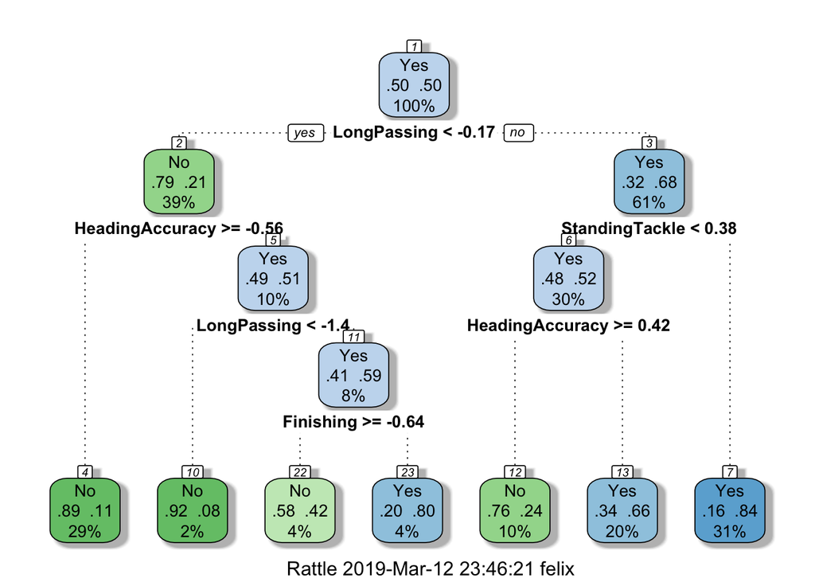

```r
fancyRpartPlot(model_dt$finalModel)
```

#### Logistic Regression Confusion Matrix and Accuracy on Test Dataset

Logistic Regression Accuracy: 0.8185

```r
confusionMatrix(predict(model_lgr,test),as.factor(test$Defense),positive = 'Yes')
```

```
## Confusion Matrix and Statistics
##
##           Reference
## Prediction  No Yes
##        No  532 183
##        Yes 143 938
##
##                Accuracy : 0.8185
##                  95% CI : (0.7999, 0.8361)
##     No Information Rate : 0.6242
##     P-Value [Acc > NIR] : < 2e-16
##
##                   Kappa : 0.6176
##  Mcnemar's Test P-Value : 0.03077
##
##             Sensitivity : 0.8368
##             Specificity : 0.7881
##          Pos Pred Value : 0.8677
##          Neg Pred Value : 0.7441
##              Prevalence : 0.6242
##          Detection Rate : 0.5223
##    Detection Prevalence : 0.6019
##       Balanced Accuracy : 0.8125
##
##        'Positive' Class : Yes
##
```

#### Decision Tree Confusion Matrix and Accuracy on Test Dataset

Decision Tree Accuracy: 0.8062

```r
confusionMatrix(predict(model_dt,test),as.factor(test$Defense),positive = 'Yes')
```

```
## Confusion Matrix and Statistics
##
##           Reference
## Prediction  No Yes
##        No  490 163
##        Yes 185 958
##
##                Accuracy : 0.8062
##                  95% CI : (0.7872, 0.8243)
##     No Information Rate : 0.6242
##     P-Value [Acc > NIR] : <2e-16
##
##                   Kappa : 0.5843
##  Mcnemar's Test P-Value : 0.2603
##
##             Sensitivity : 0.8546
##             Specificity : 0.7259
##          Pos Pred Value : 0.8381
##          Neg Pred Value : 0.7504
##              Prevalence : 0.6242
##          Detection Rate : 0.5334
##    Detection Prevalence : 0.6364
##       Balanced Accuracy : 0.7903
##
##        'Positive' Class : Yes
##
```

**[Task 4]** (10 marks): Analyze the importance of the different attributes in your best model of [Task 3]. Report the top 3 most important attributes in decreasing order of importance and explain their relevance for the classification task.

#### Decision Tree Top 3 Most Important Attributes

Top 3 Most Important Attributes  
1. StandingTackle  
2. LongPassing  
3. HeadingAccuracy

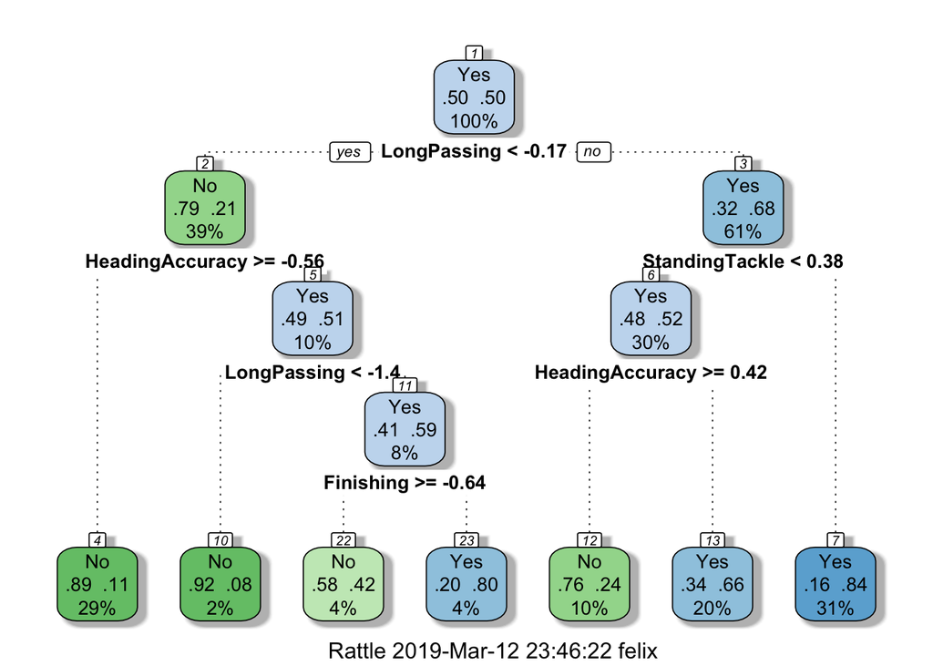

```r
fancyRpartPlot(model_dt$finalModel)
```

- The three attributes are the most important because they are the nodes at the top level of the decision tree that determines the split.
- StandingTackle is more important than LongPassing because it only appears as a parent node once in the decision tree, while LongPassing and Heading Accuracy appears twice as parents nodes in the tree.
- From the leaf node classifying “Yes”, StandingTackle classifies 31% of the training dataset,so the value of StandingTackle gives the most information for predicting the classification of “Defense”

```r
varImp(model_dt)
```

```
## rpart variable importance
##
##                 Overall
## StandingTackle  100.000
## LongPassing      81.801
## HeadingAccuracy  80.272
## Marking          70.191
## Finishing        49.917
## ShortPassing     36.145
## Positioning      17.889
## Strength         14.897
## Reactions         4.638
## Curve             1.280
## Composure         0.000
## FKAccuracy        0.000
## Vision            0.000
## Wage              0.000
```

**[Task 5]** (10 marks): Using your best model of [Task 3], is it possible to know which attributes affect positively/negatively the chance of a given player being a “Defense” player? Explain why.

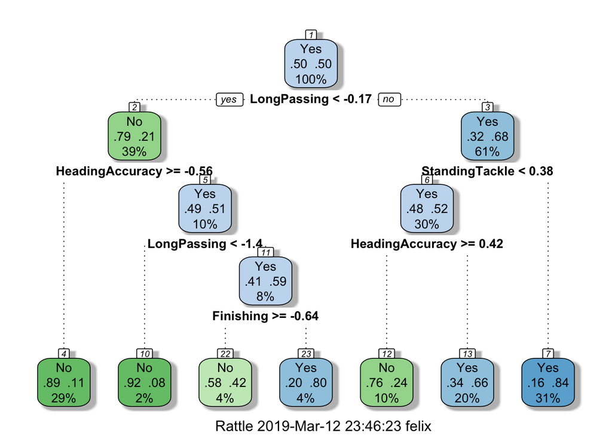

```r
fancyRpartPlot(model_dt$finalModel)
```

Yes, based on the decision tree plot it is possible to determine how increasing or decreasing the value of an attribute has on the probability of classifying a player as “Defense”.  
Lower level tree nodes are affected by the conditional value for the parent nodes, so the value of the parent node has a large affect on either increasing or decreasing the chance of classifying as “Defense”.

**[Task 6]** (15 marks): Choose one random observation from the test dataset and get its label prediction from the best model of [Task 3]. Explain, as much as possible, why the model predicted such label, in terms of the observation’s attributes.

```r
# Remove insignicant attributes, like in train_selec
random_ob <- test[,!names(test) %in%
                       c("Age",
                         "Value",
                         "Height",
                         "Weight",
                         "Crossing",
                         "Volleys",
                         "Dribbling",
                         "BallControl",
                         "Acceleration",
                         "SprintSpeed",
                         "Agility",
                         "Balance",
                         "ShotPower",
                         "Jumping",
                         "Stamina",
                         "LongShots",
                         "Aggression",
                         "SlidingTackle",
                         "Preferred.Foot",
                         "Penalties",
                         "Release.Clause"
                         )]

#Get the value of Defense for the firth row of the test dataset
print("Defense Classification for fifth row in test dataset")
```

```
## [1] "Defense Classification for fifth row in test dataset"
```

```r
random_ob[5,]$Defense
```

```
## [1] Yes
## Levels: No Yes
```

```r
#Normalize the data for interpretation,leave out Defense attribute
random_ob <- scale(random_ob[1:15],center=TRUE,scale=TRUE)


print("Normalized Row 5 in test dataset")
```

```
## [1] "Normalized Row 5 in test dataset"
```

```r
random_ob[5,]
```

```
##            Wage       Finishing HeadingAccuracy    ShortPassing
##       8.1725270       1.8130998      -0.2000884       2.9199092
##           Curve      FKAccuracy     LongPassing       Reactions
##       2.2927449       2.5445598       2.4916241       2.7869601
##        Strength   Interceptions     Positioning          Vision
##      -0.3525990       0.8977509       2.1302450       2.9711124
##       Composure         Marking  StandingTackle
##       2.6217528       1.0818202       0.9247996
```

#### Predict random observation using Decision Tree

```r
#Predict class using decision tree
predict(model_dt,test[5,])
```

```
## [1] Yes
## Levels: No Yes
```

Observed Values for Row 5 of test dataset:  
- Standing Tackle = 0.9247996  
- LongPassing = 2.4916241  
- HeadingAccuracy = -0.2000884  
- Finishing = 1.8130998

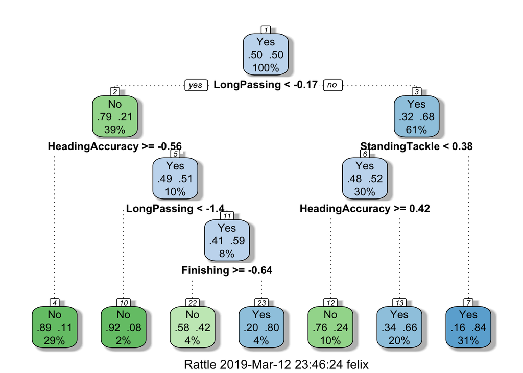

```r
fancyRpartPlot(model_dt$finalModel)
```

From the decision tree plot:  
- LongPassing is greater than -0.17  
- StandingTackle > 0.38  
- So the observation will be classified as “Yes” for assigning player as “Defense”

### Comparing Scenarios A and B

**[Task 7]** (15 marks): Compare the results of the models of [Task 1] and [Task 3]. Was there anytrade-off between interpretability and prediction accuracy? Explain.

Prediction Accuracies for model on Test Dataset:  
- Random Forest: 0.8318  
- Extreme Gradient Boosting: 0.8101  
- Logistic Regression: 0.8185  
- Decision Tree: 0.8062

Yes, Random Forest was the most accurate model, but is hard to interpret.  
Decision Tree has the lowest prediction accuracy, but is the easiest to interpret.

- The models that are more accurate are also more complex.
- The increased complexity allows the training to use more factors to predict the class.
- The increased complexity also makes it harder to interpret what parts of the data affect the prediction of the class as well as how significant each part of the data is in prediction.
- Logistic Regression is more accurate than Decision Tree, but it is harder to interpret the results because it cannot be visualized as easily.
- Random Forest is an essemble classifier of individual decision trees, so overfitting is reduced during training to increase accuracy on the test dataset, but it is harder to interpret which attributes have the largest affect on classification because it cannot be plotted and visualized as easily as the Decision Tree model.